# Risk Factor Analysis

## Outcome Variable

**Outcome Variable:** y_rate_len

## Predictor Variables

**Intervention Variable:** impsan

**Adjustment Set:**

- arm
- sex
- W_mage
- meducyrs
- feducyrs
- hhwealth_quart
- hfoodsec
- W_mhtcm
- W_mwtkg
- W_mbmi
- single
- W_nrooms
- W_parity
- impfloor
- safeh20
- delta_W_mage
- delta_meducyrs
- delta_feducyrs
- delta_hhwealth_quart
- delta_hfoodsec
- delta_W_mhtcm
- delta_W_mwtkg
- delta_W_mbmi
- delta_single
- delta_W_nrooms
- delta_W_parity
- delta_impfloor
- delta_safeh20

## Stratifying Variables

The analysis was stratified on these variable(s):

- agecat
- studyid
- country

## Data Summary

| agecat | studyid | country | impsan | n_cell | n |
| --- | --- | --- | --- | --- | --- |
| 0-3 months | COHORTS | GUATEMALA | 1 | 42 | 445 |
| 0-3 months | COHORTS | GUATEMALA | 0 | 403 | 445 |
| 0-3 months | COHORTS | INDIA | 1 | 1732 | 4660 |
| 0-3 months | COHORTS | INDIA | 0 | 2928 | 4660 |
| 0-3 months | CONTENT | PERU | 1 | 25 | 29 |
| 0-3 months | CONTENT | PERU | 0 | 4 | 29 |
| 0-3 months | JiVitA-3 | BANGLADESH | 1 | 13595 | 19861 |
| 0-3 months | JiVitA-3 | BANGLADESH | 0 | 6266 | 19861 |
| 0-3 months | JiVitA-4 | BANGLADESH | 1 | 1398 | 1805 |
| 0-3 months | JiVitA-4 | BANGLADESH | 0 | 407 | 1805 |
| 0-3 months | MAL-ED | BANGLADESH | 1 | 198 | 236 |
| 0-3 months | MAL-ED | BANGLADESH | 0 | 38 | 236 |
| 0-3 months | MAL-ED | BRAZIL | 1 | 159 | 163 |
| 0-3 months | MAL-ED | BRAZIL | 0 | 4 | 163 |
| 0-3 months | MAL-ED | INDIA | 1 | 80 | 176 |
| 0-3 months | MAL-ED | INDIA | 0 | 96 | 176 |
| 0-3 months | MAL-ED | NEPAL | 1 | 154 | 155 |
| 0-3 months | MAL-ED | NEPAL | 0 | 1 | 155 |
| 0-3 months | MAL-ED | PERU | 1 | 60 | 246 |
| 0-3 months | MAL-ED | PERU | 0 | 186 | 246 |
| 0-3 months | MAL-ED | SOUTH AFRICA | 1 | 2 | 194 |
| 0-3 months | MAL-ED | SOUTH AFRICA | 0 | 192 | 194 |
| 0-3 months | MAL-ED | TANZANIA, UNITED REPUBLIC OF | 1 | 0 | 216 |
| 0-3 months | MAL-ED | TANZANIA, UNITED REPUBLIC OF | 0 | 216 | 216 |
| 0-3 months | NIH-Birth | BANGLADESH | 1 | 218 | 566 |
| 0-3 months | NIH-Birth | BANGLADESH | 0 | 348 | 566 |
| 0-3 months | NIH-Crypto | BANGLADESH | 1 | 626 | 710 |
| 0-3 months | NIH-Crypto | BANGLADESH | 0 | 84 | 710 |
| 0-3 months | PROVIDE | BANGLADESH | 1 | 13 | 13 |
| 0-3 months | PROVIDE | BANGLADESH | 0 | 0 | 13 |

[output cut: 198 more lines]

The following strata were considered:

- agecat: 0-3 months, studyid: COHORTS, country: GUATEMALA
- agecat: 0-3 months, studyid: COHORTS, country: INDIA
- agecat: 0-3 months, studyid: CONTENT, country: PERU
- agecat: 0-3 months, studyid: JiVitA-3, country: BANGLADESH
- agecat: 0-3 months, studyid: JiVitA-4, country: BANGLADESH
- agecat: 0-3 months, studyid: MAL-ED, country: BANGLADESH
- agecat: 0-3 months, studyid: MAL-ED, country: BRAZIL
- agecat: 0-3 months, studyid: MAL-ED, country: INDIA
- agecat: 0-3 months, studyid: MAL-ED, country: NEPAL
- agecat: 0-3 months, studyid: MAL-ED, country: PERU
- agecat: 0-3 months, studyid: MAL-ED, country: SOUTH AFRICA
- agecat: 0-3 months, studyid: MAL-ED, country: TANZANIA, UNITED REPUBLIC OF
- agecat: 0-3 months, studyid: NIH-Birth, country: BANGLADESH
- agecat: 0-3 months, studyid: NIH-Crypto, country: BANGLADESH
- agecat: 0-3 months, studyid: PROVIDE, country: BANGLADESH
- agecat: 12-15 months, studyid: COHORTS, country: GUATEMALA
- agecat: 12-15 months, studyid: CONTENT, country: PERU
- agecat: 12-15 months, studyid: JiVitA-4, country: BANGLADESH
- agecat: 12-15 months, studyid: LCNI-5, country: MALAWI
- agecat: 12-15 months, studyid: MAL-ED, country: BANGLADESH
- agecat: 12-15 months, studyid: MAL-ED, country: BRAZIL
- agecat: 12-15 months, studyid: MAL-ED, country: INDIA
- agecat: 12-15 months, studyid: MAL-ED, country: NEPAL
- agecat: 12-15 months, studyid: MAL-ED, country: PERU
- agecat: 12-15 months, studyid: MAL-ED, country: SOUTH AFRICA
- agecat: 12-15 months, studyid: MAL-ED, country: TANZANIA, UNITED REPUBLIC OF
- agecat: 12-15 months, studyid: NIH-Birth, country: BANGLADESH
- agecat: 12-15 months, studyid: NIH-Crypto, country: BANGLADESH
- agecat: 12-15 months, studyid: PROVIDE, country: BANGLADESH
- agecat: 15-18 months, studyid: COHORTS, country: GUATEMALA
- agecat: 15-18 months, studyid: CONTENT, country: PERU
- agecat: 15-18 months, studyid: JiVitA-4, country: BANGLADESH
- agecat: 15-18 months, studyid: LCNI-5, country: MALAWI
- agecat: 15-18 months, studyid: MAL-ED, country: BANGLADESH
- agecat: 15-18 months, studyid: MAL-ED, country: BRAZIL
- agecat: 15-18 months, studyid: MAL-ED, country: INDIA
- agecat: 15-18 months, studyid: MAL-ED, country: NEPAL
- agecat: 15-18 months, studyid: MAL-ED, country: PERU
- agecat: 15-18 months, studyid: MAL-ED, country: SOUTH AFRICA
- agecat: 15-18 months, studyid: MAL-ED, country: TANZANIA, UNITED REPUBLIC OF
- agecat: 15-18 months, studyid: NIH-Birth, country: BANGLADESH
- agecat: 15-18 months, studyid: NIH-Crypto, country: BANGLADESH
- agecat: 15-18 months, studyid: PROVIDE, country: BANGLADESH
- agecat: 18-21 months, studyid: COHORTS, country: GUATEMALA
- agecat: 18-21 months, studyid: CONTENT, country: PERU
- agecat: 18-21 months, studyid: LCNI-5, country: MALAWI
- agecat: 18-21 months, studyid: MAL-ED, country: BANGLADESH
- agecat: 18-21 months, studyid: MAL-ED, country: BRAZIL
- agecat: 18-21 months, studyid: MAL-ED, country: INDIA
- agecat: 18-21 months, studyid: MAL-ED, country: NEPAL
- agecat: 18-21 months, studyid: MAL-ED, country: PERU
- agecat: 18-21 months, studyid: MAL-ED, country: SOUTH AFRICA
- agecat: 18-21 months, studyid: MAL-ED, country: TANZANIA, UNITED REPUBLIC OF
- agecat: 18-21 months, studyid: NIH-Birth, country: BANGLADESH
- agecat: 18-21 months, studyid: NIH-Crypto, country: BANGLADESH
- agecat: 18-21 months, studyid: PROVIDE, country: BANGLADESH
- agecat: 21-24 months, studyid: COHORTS, country: GUATEMALA
- agecat: 21-24 months, studyid: CONTENT, country: PERU
- agecat: 21-24 months, studyid: LCNI-5, country: MALAWI
- agecat: 21-24 months, studyid: MAL-ED, country: BANGLADESH
- agecat: 21-24 months, studyid: MAL-ED, country: BRAZIL
- agecat: 21-24 months, studyid: MAL-ED, country: INDIA
- agecat: 21-24 months, studyid: MAL-ED, country: NEPAL
- agecat: 21-24 months, studyid: MAL-ED, country: PERU
- agecat: 21-24 months, studyid: MAL-ED, country: SOUTH AFRICA
- agecat: 21-24 months, studyid: MAL-ED, country: TANZANIA, UNITED REPUBLIC OF
- agecat: 21-24 months, studyid: NIH-Birth, country: BANGLADESH
- agecat: 21-24 months, studyid: NIH-Crypto, country: BANGLADESH
- agecat: 21-24 months, studyid: PROVIDE, country: BANGLADESH
- agecat: 3-6 months, studyid: COHORTS, country: GUATEMALA
- agecat: 3-6 months, studyid: COHORTS, country: INDIA
- agecat: 3-6 months, studyid: CONTENT, country: PERU
- agecat: 3-6 months, studyid: JiVitA-3, country: BANGLADESH
- agecat: 3-6 months, studyid: JiVitA-4, country: BANGLADESH
- agecat: 3-6 months, studyid: MAL-ED, country: BANGLADESH
- agecat: 3-6 months, studyid: MAL-ED, country: BRAZIL
- agecat: 3-6 months, studyid: MAL-ED, country: INDIA
- agecat: 3-6 months, studyid: MAL-ED, country: NEPAL
- agecat: 3-6 months, studyid: MAL-ED, country: PERU
- agecat: 3-6 months, studyid: MAL-ED, country: SOUTH AFRICA
- agecat: 3-6 months, studyid: MAL-ED, country: TANZANIA, UNITED REPUBLIC OF
- agecat: 3-6 months, studyid: NIH-Birth, country: BANGLADESH
- agecat: 3-6 months, studyid: NIH-Crypto, country: BANGLADESH
- agecat: 3-6 months, studyid: PROVIDE, country: BANGLADESH
- agecat: 6-9 months, studyid: COHORTS, country: GUATEMALA
- agecat: 6-9 months, studyid: COHORTS, country: INDIA
- agecat: 6-9 months, studyid: CONTENT, country: PERU
- agecat: 6-9 months, studyid: JiVitA-4, country: BANGLADESH
- agecat: 6-9 months, studyid: LCNI-5, country: MALAWI
- agecat: 6-9 months, studyid: MAL-ED, country: BANGLADESH
- agecat: 6-9 months, studyid: MAL-ED, country: BRAZIL
- agecat: 6-9 months, studyid: MAL-ED, country: INDIA
- agecat: 6-9 months, studyid: MAL-ED, country: NEPAL
- agecat: 6-9 months, studyid: MAL-ED, country: PERU
- agecat: 6-9 months, studyid: MAL-ED, country: SOUTH AFRICA
- agecat: 6-9 months, studyid: MAL-ED, country: TANZANIA, UNITED REPUBLIC OF
- agecat: 6-9 months, studyid: NIH-Birth, country: BANGLADESH
- agecat: 6-9 months, studyid: NIH-Crypto, country: BANGLADESH
- agecat: 6-9 months, studyid: PROVIDE, country: BANGLADESH
- agecat: 9-12 months, studyid: COHORTS, country: GUATEMALA
- agecat: 9-12 months, studyid: COHORTS, country: INDIA
- agecat: 9-12 months, studyid: CONTENT, country: PERU
- agecat: 9-12 months, studyid: JiVitA-4, country: BANGLADESH
- agecat: 9-12 months, studyid: LCNI-5, country: MALAWI
- agecat: 9-12 months, studyid: MAL-ED, country: BANGLADESH
- agecat: 9-12 months, studyid: MAL-ED, country: BRAZIL
- agecat: 9-12 months, studyid: MAL-ED, country: INDIA
- agecat: 9-12 months, studyid: MAL-ED, country: NEPAL
- agecat: 9-12 months, studyid: MAL-ED, country: PERU
- agecat: 9-12 months, studyid: MAL-ED, country: SOUTH AFRICA
- agecat: 9-12 months, studyid: MAL-ED, country: TANZANIA, UNITED REPUBLIC OF
- agecat: 9-12 months, studyid: NIH-Birth, country: BANGLADESH
- agecat: 9-12 months, studyid: NIH-Crypto, country: BANGLADESH
- agecat: 9-12 months, studyid: PROVIDE, country: BANGLADESH

### Dropped Strata

- agecat: 0-3 months, studyid: CONTENT, country: PERU
- agecat: 0-3 months, studyid: MAL-ED, country: BRAZIL
- agecat: 0-3 months, studyid: MAL-ED, country: NEPAL
- agecat: 0-3 months, studyid: MAL-ED, country: SOUTH AFRICA
- agecat: 0-3 months, studyid: MAL-ED, country: TANZANIA, UNITED REPUBLIC OF
- agecat: 0-3 months, studyid: PROVIDE, country: BANGLADESH
- agecat: 3-6 months, studyid: MAL-ED, country: BRAZIL
- agecat: 3-6 months, studyid: MAL-ED, country: NEPAL
- agecat: 3-6 months, studyid: MAL-ED, country: SOUTH AFRICA
- agecat: 3-6 months, studyid: MAL-ED, country: TANZANIA, UNITED REPUBLIC OF
- agecat: 3-6 months, studyid: PROVIDE, country: BANGLADESH
- agecat: 6-9 months, studyid: LCNI-5, country: MALAWI
- agecat: 6-9 months, studyid: MAL-ED, country: BRAZIL
- agecat: 6-9 months, studyid: MAL-ED, country: NEPAL
- agecat: 6-9 months, studyid: MAL-ED, country: SOUTH AFRICA
- agecat: 6-9 months, studyid: MAL-ED, country: TANZANIA, UNITED REPUBLIC OF
- agecat: 6-9 months, studyid: PROVIDE, country: BANGLADESH
- agecat: 9-12 months, studyid: LCNI-5, country: MALAWI
- agecat: 9-12 months, studyid: MAL-ED, country: BRAZIL
- agecat: 9-12 months, studyid: MAL-ED, country: NEPAL
- agecat: 9-12 months, studyid: MAL-ED, country: SOUTH AFRICA
- agecat: 9-12 months, studyid: MAL-ED, country: TANZANIA, UNITED REPUBLIC OF
- agecat: 9-12 months, studyid: PROVIDE, country: BANGLADESH
- agecat: 12-15 months, studyid: LCNI-5, country: MALAWI
- agecat: 12-15 months, studyid: MAL-ED, country: BRAZIL
- agecat: 12-15 months, studyid: MAL-ED, country: NEPAL
- agecat: 12-15 months, studyid: MAL-ED, country: SOUTH AFRICA
- agecat: 12-15 months, studyid: MAL-ED, country: TANZANIA, UNITED REPUBLIC OF
- agecat: 12-15 months, studyid: PROVIDE, country: BANGLADESH
- agecat: 15-18 months, studyid: LCNI-5, country: MALAWI
- agecat: 15-18 months, studyid: MAL-ED, country: BRAZIL
- agecat: 15-18 months, studyid: MAL-ED, country: NEPAL
- agecat: 15-18 months, studyid: MAL-ED, country: SOUTH AFRICA
- agecat: 15-18 months, studyid: MAL-ED, country: TANZANIA, UNITED REPUBLIC OF
- agecat: 15-18 months, studyid: PROVIDE, country: BANGLADESH
- agecat: 18-21 months, studyid: LCNI-5, country: MALAWI
- agecat: 18-21 months, studyid: MAL-ED, country: BRAZIL
- agecat: 18-21 months, studyid: MAL-ED, country: NEPAL
- agecat: 18-21 months, studyid: MAL-ED, country: SOUTH AFRICA
- agecat: 18-21 months, studyid: MAL-ED, country: TANZANIA, UNITED REPUBLIC OF
- agecat: 18-21 months, studyid: PROVIDE, country: BANGLADESH
- agecat: 21-24 months, studyid: CONTENT, country: PERU
- agecat: 21-24 months, studyid: LCNI-5, country: MALAWI
- agecat: 21-24 months, studyid: MAL-ED, country: BRAZIL
- agecat: 21-24 months, studyid: MAL-ED, country: NEPAL
- agecat: 21-24 months, studyid: MAL-ED, country: SOUTH AFRICA
- agecat: 21-24 months, studyid: MAL-ED, country: TANZANIA, UNITED REPUBLIC OF
- agecat: 21-24 months, studyid: PROVIDE, country: BANGLADESH

## Methods Detail

We’re interested in the causal parameters $E[Y_a]$ for all values of $a \in \mathcal{A}$. These parameters represent the mean outcome if, possibly contrary to fact, we intervened to set all units to have $A=a$. Under the randomization and positivity assumptions, these are identified by the statistical parameters $\psi_a=E_W[E_{Y|A,W}(Y|A=a,W)]$. In addition, we’re interested in the mean of $Y$, $E[Y]$ under no intervention (the observed mean). We will estimate these parameters by using SuperLearner to fit the relevant likelihood factors – $E_{Y|A,W}(Y|A=a,W)$ and $p(A=a|W)$, and then updating our likelihood fit using a joint TMLE.

For unadjusted analyses ($W=\{\}$), initial likelihoods were estimated using Lrnr_glm to estimate the simple $E(Y|A)$ and Lrnr_mean to estimate $p(A)$. For adjusted analyses, a small library containing Lrnr_glmnet, Lrnr_xgboost, and Lrnr_mean was used.

Having estimated these parameters, we will then use the delta method to estimate relative risks and attributable risks relative to a prespecified baseline level of $A$.

# Results Detail

## Results Plots

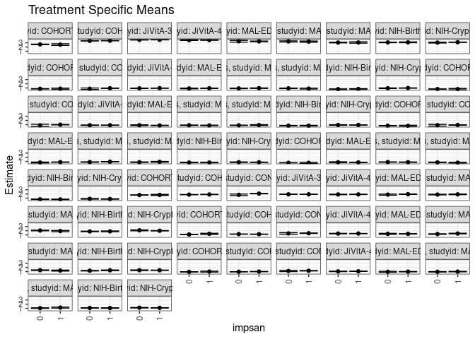

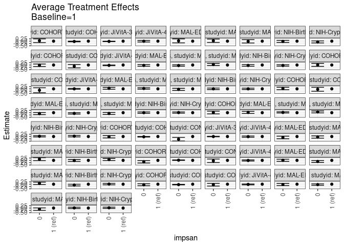

[figure not shown]

## Results Table

### Parameter: TSM

| agecat | studyid | country | intervention_level | baseline_level | estimate | ci_lower | ci_upper |
| --- | --- | --- | --- | --- | --- | --- | --- |
| 0-3 months | COHORTS | GUATEMALA | 1 | NA | 2.5772755 | 2.3838741 | 2.7706769 |
| 0-3 months | COHORTS | GUATEMALA | 0 | NA | 2.6229749 | 2.5655294 | 2.6804204 |
| 0-3 months | COHORTS | INDIA | 1 | NA | 3.5135057 | 3.4846903 | 3.5423211 |
| 0-3 months | COHORTS | INDIA | 0 | NA | 3.4783502 | 3.4563241 | 3.5003763 |
| 0-3 months | JiVitA-3 | BANGLADESH | 1 | NA | 3.7259894 | 3.7134279 | 3.7385509 |
| 0-3 months | JiVitA-3 | BANGLADESH | 0 | NA | 3.7002521 | 3.6785581 | 3.7219460 |
| 0-3 months | JiVitA-4 | BANGLADESH | 1 | NA | 3.6471002 | 3.6112366 | 3.6829638 |
| 0-3 months | JiVitA-4 | BANGLADESH | 0 | NA | 3.6380365 | 3.5610160 | 3.7150571 |
| 0-3 months | MAL-ED | BANGLADESH | 1 | NA | 3.3414459 | 3.2730713 | 3.4098204 |
| 0-3 months | MAL-ED | BANGLADESH | 0 | NA | 3.3746223 | 3.1691110 | 3.5801337 |
| 0-3 months | MAL-ED | INDIA | 1 | NA | 3.2922700 | 3.1632310 | 3.4213089 |
| 0-3 months | MAL-ED | INDIA | 0 | NA | 3.3345949 | 3.2067412 | 3.4624487 |
| 0-3 months | MAL-ED | PERU | 1 | NA | 3.0837846 | 2.9194159 | 3.2481533 |
| 0-3 months | MAL-ED | PERU | 0 | NA | 3.0658729 | 2.9902456 | 3.1415001 |
| 0-3 months | NIH-Birth | BANGLADESH | 1 | NA | 3.1260446 | 3.0357136 | 3.2163755 |
| 0-3 months | NIH-Birth | BANGLADESH | 0 | NA | 3.0995779 | 3.0337458 | 3.1654101 |
| 0-3 months | NIH-Crypto | BANGLADESH | 1 | NA | 3.1433969 | 3.1040133 | 3.1827806 |
| 0-3 months | NIH-Crypto | BANGLADESH | 0 | NA | 3.0611192 | 2.9605259 | 3.1617124 |
| 3-6 months | COHORTS | GUATEMALA | 1 | NA | 1.7725827 | 1.6505656 | 1.8945998 |
| 3-6 months | COHORTS | GUATEMALA | 0 | NA | 1.7465730 | 1.7060640 | 1.7870820 |
| 3-6 months | COHORTS | INDIA | 1 | NA | 1.8727507 | 1.8490118 | 1.8964895 |
| 3-6 months | COHORTS | INDIA | 0 | NA | 1.8454463 | 1.8270005 | 1.8638921 |
| 3-6 months | CONTENT | PERU | 1 | NA | 2.0891694 | 2.0397846 | 2.1385542 |
| 3-6 months | CONTENT | PERU | 0 | NA | 1.7957696 | 1.6079158 | 1.9836234 |
| 3-6 months | JiVitA-3 | BANGLADESH | 1 | NA | 1.9212811 | 1.9084666 | 1.9340955 |
| 3-6 months | JiVitA-3 | BANGLADESH | 0 | NA | 1.9197664 | 1.8960625 | 1.9434703 |
| 3-6 months | JiVitA-4 | BANGLADESH | 1 | NA | 1.8968979 | 1.8630891 | 1.9307066 |
| 3-6 months | JiVitA-4 | BANGLADESH | 0 | NA | 1.8859380 | 1.8272071 | 1.9446690 |
| 3-6 months | MAL-ED | BANGLADESH | 1 | NA | 1.9445872 | 1.8895380 | 1.9996363 |
| 3-6 months | MAL-ED | BANGLADESH | 0 | NA | 1.8460730 | 1.7150299 | 1.9771162 |

[output cut: 102 more lines]

### Parameter: E(Y)

| agecat | studyid | country | intervention_level | baseline_level | estimate | ci_lower | ci_upper |
| --- | --- | --- | --- | --- | --- | --- | --- |
| 0-3 months | COHORTS | GUATEMALA | NA | NA | 2.6177358 | 2.5631597 | 2.6723119 |
| 0-3 months | COHORTS | INDIA | NA | NA | 3.4938034 | 3.4771179 | 3.5104888 |
| 0-3 months | JiVitA-3 | BANGLADESH | NA | NA | 3.7233638 | 3.7130612 | 3.7336665 |
| 0-3 months | JiVitA-4 | BANGLADESH | NA | NA | 3.6386177 | 3.6075243 | 3.6697112 |
| 0-3 months | MAL-ED | BANGLADESH | NA | NA | 3.3470101 | 3.2814494 | 3.4125709 |
| 0-3 months | MAL-ED | INDIA | NA | NA | 3.3257529 | 3.2359780 | 3.4155278 |
| 0-3 months | MAL-ED | PERU | NA | NA | 3.0728777 | 3.0062000 | 3.1395554 |
| 0-3 months | NIH-Birth | BANGLADESH | NA | NA | 3.1100116 | 3.0566021 | 3.1634210 |
| 0-3 months | NIH-Crypto | BANGLADESH | NA | NA | 3.1335342 | 3.0968946 | 3.1701738 |
| 3-6 months | COHORTS | GUATEMALA | NA | NA | 1.7541195 | 1.7166655 | 1.7915734 |
| 3-6 months | COHORTS | INDIA | NA | NA | 1.8572103 | 1.8432112 | 1.8712094 |
| 3-6 months | CONTENT | PERU | NA | NA | 2.0841841 | 2.0362519 | 2.1321163 |
| 3-6 months | JiVitA-3 | BANGLADESH | NA | NA | 1.9202191 | 1.9097529 | 1.9306852 |
| 3-6 months | JiVitA-4 | BANGLADESH | NA | NA | 1.8987567 | 1.8688242 | 1.9286892 |
| 3-6 months | MAL-ED | BANGLADESH | NA | NA | 1.9276407 | 1.8774065 | 1.9778750 |
| 3-6 months | MAL-ED | INDIA | NA | NA | 1.8780654 | 1.8173074 | 1.9388233 |
| 3-6 months | MAL-ED | PERU | NA | NA | 2.0175680 | 1.9512051 | 2.0839310 |
| 3-6 months | NIH-Birth | BANGLADESH | NA | NA | 1.8326915 | 1.7846731 | 1.8807099 |
| 3-6 months | NIH-Crypto | BANGLADESH | NA | NA | 2.0027540 | 1.9667312 | 2.0387768 |
| 6-9 months | COHORTS | GUATEMALA | NA | NA | 1.1046168 | 1.0728025 | 1.1364310 |
| 6-9 months | COHORTS | INDIA | NA | NA | 1.1818282 | 1.1689263 | 1.1947301 |
| 6-9 months | CONTENT | PERU | NA | NA | 1.3974236 | 1.3502187 | 1.4446285 |
| 6-9 months | JiVitA-4 | BANGLADESH | NA | NA | 1.3241671 | 1.3034835 | 1.3448507 |
| 6-9 months | MAL-ED | BANGLADESH | NA | NA | 1.2480451 | 1.2083209 | 1.2877694 |
| 6-9 months | MAL-ED | INDIA | NA | NA | 1.2581259 | 1.2101884 | 1.3060633 |
| 6-9 months | MAL-ED | PERU | NA | NA | 1.3204373 | 1.2649539 | 1.3759207 |
| 6-9 months | NIH-Birth | BANGLADESH | NA | NA | 1.2555950 | 1.2150667 | 1.2961234 |
| 6-9 months | NIH-Crypto | BANGLADESH | NA | NA | 1.3277672 | 1.2982110 | 1.3573234 |
| 9-12 months | COHORTS | GUATEMALA | NA | NA | 0.9427431 | 0.9140297 | 0.9714566 |
| 9-12 months | COHORTS | INDIA | NA | NA | 0.9844431 | 0.9705367 | 0.9983496 |
| 9-12 months | CONTENT | PERU | NA | NA | 1.2048768 | 1.1650186 | 1.2447350 |
| 9-12 months | JiVitA-4 | BANGLADESH | NA | NA | 1.0714466 | 1.0534634 | 1.0894298 |
| 9-12 months | MAL-ED | BANGLADESH | NA | NA | 0.9896446 | 0.9509752 | 1.0283140 |
| 9-12 months | MAL-ED | INDIA | NA | NA | 0.9810598 | 0.9425271 | 1.0195925 |
| 9-12 months | MAL-ED | PERU | NA | NA | 1.0938158 | 1.0421876 | 1.1454440 |
| 9-12 months | NIH-Birth | BANGLADESH | NA | NA | 1.0885809 | 1.0534446 | 1.1237171 |
| 9-12 months | NIH-Crypto | BANGLADESH | NA | NA | 1.1253061 | 1.0988172 | 1.1517949 |
| 12-15 months | COHORTS | GUATEMALA | NA | NA | 0.7899732 | 0.7616006 | 0.8183457 |
| 12-15 months | CONTENT | PERU | NA | NA | 0.9291443 | 0.8867697 | 0.9715190 |
| 12-15 months | JiVitA-4 | BANGLADESH | NA | NA | 0.9414130 | 0.9256041 | 0.9572219 |
| 12-15 months | MAL-ED | BANGLADESH | NA | NA | 0.9141004 | 0.8737459 | 0.9544550 |
| 12-15 months | MAL-ED | INDIA | NA | NA | 0.9129447 | 0.8748557 | 0.9510337 |
| 12-15 months | MAL-ED | PERU | NA | NA | 0.8895957 | 0.8424004 | 0.9367911 |
| 12-15 months | NIH-Birth | BANGLADESH | NA | NA | 0.7241623 | 0.6797013 | 0.7686233 |
| 12-15 months | NIH-Crypto | BANGLADESH | NA | NA | 0.9714857 | 0.9466423 | 0.9963290 |
| 15-18 months | COHORTS | GUATEMALA | NA | NA | 0.7357057 | 0.7024388 | 0.7689726 |
| 15-18 months | CONTENT | PERU | NA | NA | 0.9860231 | 0.9406097 | 1.0314365 |
| 15-18 months | JiVitA-4 | BANGLADESH | NA | NA | 0.8599047 | 0.8433807 | 0.8764287 |
| 15-18 months | MAL-ED | BANGLADESH | NA | NA | 0.8241226 | 0.7871907 | 0.8610544 |
| 15-18 months | MAL-ED | INDIA | NA | NA | 0.8461081 | 0.8096109 | 0.8826053 |
| 15-18 months | MAL-ED | PERU | NA | NA | 0.8582871 | 0.8154498 | 0.9011244 |
| 15-18 months | NIH-Birth | BANGLADESH | NA | NA | 0.7727719 | 0.7325606 | 0.8129832 |
| 15-18 months | NIH-Crypto | BANGLADESH | NA | NA | 0.9162288 | 0.8930973 | 0.9393604 |
| 18-21 months | COHORTS | GUATEMALA | NA | NA | 0.7453230 | 0.7139167 | 0.7767294 |
| 18-21 months | CONTENT | PERU | NA | NA | 0.9146338 | 0.8709588 | 0.9583088 |
| 18-21 months | MAL-ED | BANGLADESH | NA | NA | 0.8133847 | 0.7790076 | 0.8477619 |
| 18-21 months | MAL-ED | INDIA | NA | NA | 0.8786990 | 0.8431802 | 0.9142178 |
| 18-21 months | MAL-ED | PERU | NA | NA | 0.8405408 | 0.7957138 | 0.8853678 |
| 18-21 months | NIH-Birth | BANGLADESH | NA | NA | 0.7291468 | 0.6930874 | 0.7652062 |
| 18-21 months | NIH-Crypto | BANGLADESH | NA | NA | 0.7977951 | 0.7741689 | 0.8214214 |
| 21-24 months | COHORTS | GUATEMALA | NA | NA | 0.6771703 | 0.6513485 | 0.7029921 |
| 21-24 months | MAL-ED | BANGLADESH | NA | NA | 0.7694183 | 0.7339448 | 0.8048918 |
| 21-24 months | MAL-ED | INDIA | NA | NA | 0.8256267 | 0.7945621 | 0.8566913 |
| 21-24 months | MAL-ED | PERU | NA | NA | 0.7622936 | 0.7156467 | 0.8089404 |
| 21-24 months | NIH-Birth | BANGLADESH | NA | NA | 0.7172178 | 0.6817161 | 0.7527194 |
| 21-24 months | NIH-Crypto | BANGLADESH | NA | NA | 0.8010871 | 0.7761614 | 0.8260128 |

### Parameter: ATE

| agecat | studyid | country | intervention_level | baseline_level | estimate | ci_lower | ci_upper |
| --- | --- | --- | --- | --- | --- | --- | --- |
| 0-3 months | COHORTS | GUATEMALA | 1 | 1 | 0.0000000 | 0.0000000 | 0.0000000 |
| 0-3 months | COHORTS | GUATEMALA | 0 | 1 | 0.0456994 | -0.1569872 | 0.2483860 |
| 0-3 months | COHORTS | INDIA | 1 | 1 | 0.0000000 | 0.0000000 | 0.0000000 |
| 0-3 months | COHORTS | INDIA | 0 | 1 | -0.0351555 | -0.0708888 | 0.0005779 |
| 0-3 months | JiVitA-3 | BANGLADESH | 1 | 1 | 0.0000000 | 0.0000000 | 0.0000000 |
| 0-3 months | JiVitA-3 | BANGLADESH | 0 | 1 | -0.0257373 | -0.0487374 | -0.0027373 |
| 0-3 months | JiVitA-4 | BANGLADESH | 1 | 1 | 0.0000000 | 0.0000000 | 0.0000000 |
| 0-3 months | JiVitA-4 | BANGLADESH | 0 | 1 | -0.0090637 | -0.0944901 | 0.0763627 |
| 0-3 months | MAL-ED | BANGLADESH | 1 | 1 | 0.0000000 | 0.0000000 | 0.0000000 |
| 0-3 months | MAL-ED | BANGLADESH | 0 | 1 | 0.0331765 | -0.1834326 | 0.2497856 |
| 0-3 months | MAL-ED | INDIA | 1 | 1 | 0.0000000 | 0.0000000 | 0.0000000 |
| 0-3 months | MAL-ED | INDIA | 0 | 1 | 0.0423250 | -0.1406690 | 0.2253190 |
| 0-3 months | MAL-ED | PERU | 1 | 1 | 0.0000000 | 0.0000000 | 0.0000000 |
| 0-3 months | MAL-ED | PERU | 0 | 1 | -0.0179117 | -0.1990123 | 0.1631889 |
| 0-3 months | NIH-Birth | BANGLADESH | 1 | 1 | 0.0000000 | 0.0000000 | 0.0000000 |
| 0-3 months | NIH-Birth | BANGLADESH | 0 | 1 | -0.0264666 | -0.1377892 | 0.0848559 |
| 0-3 months | NIH-Crypto | BANGLADESH | 1 | 1 | 0.0000000 | 0.0000000 | 0.0000000 |
| 0-3 months | NIH-Crypto | BANGLADESH | 0 | 1 | -0.0822778 | -0.1903355 | 0.0257799 |
| 3-6 months | COHORTS | GUATEMALA | 1 | 1 | 0.0000000 | 0.0000000 | 0.0000000 |
| 3-6 months | COHORTS | GUATEMALA | 0 | 1 | -0.0260097 | -0.1549739 | 0.1029545 |
| 3-6 months | COHORTS | INDIA | 1 | 1 | 0.0000000 | 0.0000000 | 0.0000000 |
| 3-6 months | COHORTS | INDIA | 0 | 1 | -0.0273044 | -0.0572158 | 0.0026071 |
| 3-6 months | CONTENT | PERU | 1 | 1 | 0.0000000 | 0.0000000 | 0.0000000 |
| 3-6 months | CONTENT | PERU | 0 | 1 | -0.2933999 | -0.4883154 | -0.0984843 |
| 3-6 months | JiVitA-3 | BANGLADESH | 1 | 1 | 0.0000000 | 0.0000000 | 0.0000000 |
| 3-6 months | JiVitA-3 | BANGLADESH | 0 | 1 | -0.0015146 | -0.0278516 | 0.0248223 |
| 3-6 months | JiVitA-4 | BANGLADESH | 1 | 1 | 0.0000000 | 0.0000000 | 0.0000000 |
| 3-6 months | JiVitA-4 | BANGLADESH | 0 | 1 | -0.0109598 | -0.0790361 | 0.0571165 |
| 3-6 months | MAL-ED | BANGLADESH | 1 | 1 | 0.0000000 | 0.0000000 | 0.0000000 |
| 3-6 months | MAL-ED | BANGLADESH | 0 | 1 | -0.0985141 | -0.2411226 | 0.0440944 |

[output cut: 102 more lines]

### Parameter: PAR

| agecat | studyid | country | intervention_level | baseline_level | estimate | ci_lower | ci_upper |
| --- | --- | --- | --- | --- | --- | --- | --- |
| 0-3 months | COHORTS | GUATEMALA | 1 | NA | 0.0404603 | -0.1445730 | 0.2254935 |
| 0-3 months | COHORTS | INDIA | 1 | NA | -0.0197023 | -0.0434750 | 0.0040703 |
| 0-3 months | JiVitA-3 | BANGLADESH | 1 | NA | -0.0026256 | -0.0096565 | 0.0044053 |
| 0-3 months | JiVitA-4 | BANGLADESH | 1 | NA | -0.0084825 | -0.0268972 | 0.0099322 |
| 0-3 months | MAL-ED | BANGLADESH | 1 | NA | 0.0055643 | -0.0265085 | 0.0376370 |
| 0-3 months | MAL-ED | INDIA | 1 | NA | 0.0334829 | -0.0672520 | 0.1342178 |
| 0-3 months | MAL-ED | PERU | 1 | NA | -0.0109068 | -0.1531651 | 0.1313514 |
| 0-3 months | NIH-Birth | BANGLADESH | 1 | NA | -0.0160330 | -0.0845708 | 0.0525048 |
| 0-3 months | NIH-Crypto | BANGLADESH | 1 | NA | -0.0098627 | -0.0221981 | 0.0024726 |
| 3-6 months | COHORTS | GUATEMALA | 1 | NA | -0.0184632 | -0.1373173 | 0.1003908 |
| 3-6 months | COHORTS | INDIA | 1 | NA | -0.0155404 | -0.0351658 | 0.0040850 |
| 3-6 months | CONTENT | PERU | 1 | NA | -0.0049853 | -0.0194234 | 0.0094527 |
| 3-6 months | JiVitA-3 | BANGLADESH | 1 | NA | -0.0010620 | -0.0083783 | 0.0062543 |
| 3-6 months | JiVitA-4 | BANGLADESH | 1 | NA | 0.0018588 | -0.0149531 | 0.0186707 |
| 3-6 months | MAL-ED | BANGLADESH | 1 | NA | -0.0169464 | -0.0392376 | 0.0053447 |
| 3-6 months | MAL-ED | INDIA | 1 | NA | -0.0320532 | -0.0981458 | 0.0340394 |
| 3-6 months | MAL-ED | PERU | 1 | NA | 0.1041785 | -0.0228426 | 0.2311995 |
| 3-6 months | NIH-Birth | BANGLADESH | 1 | NA | -0.0123730 | -0.0787275 | 0.0539815 |
| 3-6 months | NIH-Crypto | BANGLADESH | 1 | NA | 0.0108943 | -0.0026083 | 0.0243969 |
| 6-9 months | COHORTS | GUATEMALA | 1 | NA | -0.1511531 | -0.2710454 | -0.0312607 |
| 6-9 months | COHORTS | INDIA | 1 | NA | 0.0127143 | -0.0084381 | 0.0338667 |
| 6-9 months | CONTENT | PERU | 1 | NA | -0.0029927 | -0.0143127 | 0.0083273 |
| 6-9 months | JiVitA-4 | BANGLADESH | 1 | NA | -0.0046183 | -0.0160811 | 0.0068445 |
| 6-9 months | MAL-ED | BANGLADESH | 1 | NA | 0.0017450 | -0.0171214 | 0.0206114 |
| 6-9 months | MAL-ED | INDIA | 1 | NA | -0.0650899 | -0.1190680 | -0.0111118 |
| 6-9 months | MAL-ED | PERU | 1 | NA | 0.0648596 | -0.0381334 | 0.1678527 |
| 6-9 months | NIH-Birth | BANGLADESH | 1 | NA | -0.0581185 | -0.1144312 | -0.0018058 |
| 6-9 months | NIH-Crypto | BANGLADESH | 1 | NA | 0.0007693 | -0.0096086 | 0.0111471 |
| 9-12 months | COHORTS | GUATEMALA | 1 | NA | -0.0555439 | -0.1570448 | 0.0459570 |
| 9-12 months | COHORTS | INDIA | 1 | NA | -0.0283716 | -0.0486153 | -0.0081279 |
| 9-12 months | CONTENT | PERU | 1 | NA | -0.0036824 | -0.0133579 | 0.0059930 |
| 9-12 months | JiVitA-4 | BANGLADESH | 1 | NA | -0.0038253 | -0.0143541 | 0.0067034 |
| 9-12 months | MAL-ED | BANGLADESH | 1 | NA | -0.0018638 | -0.0189552 | 0.0152276 |
| 9-12 months | MAL-ED | INDIA | 1 | NA | -0.0210016 | -0.0627538 | 0.0207506 |
| 9-12 months | MAL-ED | PERU | 1 | NA | -0.0903070 | -0.1986787 | 0.0180646 |
| 9-12 months | NIH-Birth | BANGLADESH | 1 | NA | 0.0096069 | -0.0334931 | 0.0527070 |
| 9-12 months | NIH-Crypto | BANGLADESH | 1 | NA | 0.0011830 | -0.0077767 | 0.0101427 |
| 12-15 months | COHORTS | GUATEMALA | 1 | NA | -0.0308986 | -0.1585580 | 0.0967607 |
| 12-15 months | CONTENT | PERU | 1 | NA | -0.0063521 | -0.0172759 | 0.0045717 |
| 12-15 months | JiVitA-4 | BANGLADESH | 1 | NA | -0.0021541 | -0.0111848 | 0.0068766 |
| 12-15 months | MAL-ED | BANGLADESH | 1 | NA | -0.0077220 | -0.0218830 | 0.0064390 |
| 12-15 months | MAL-ED | INDIA | 1 | NA | -0.0297966 | -0.0717586 | 0.0121654 |
| 12-15 months | MAL-ED | PERU | 1 | NA | 0.0453828 | -0.0452968 | 0.1360623 |
| 12-15 months | NIH-Birth | BANGLADESH | 1 | NA | -0.0293157 | -0.0849272 | 0.0262959 |
| 12-15 months | NIH-Crypto | BANGLADESH | 1 | NA | -0.0060803 | -0.0155405 | 0.0033800 |
| 15-18 months | COHORTS | GUATEMALA | 1 | NA | 0.0178585 | -0.1348168 | 0.1705339 |
| 15-18 months | CONTENT | PERU | 1 | NA | -0.0092200 | -0.0225252 | 0.0040853 |
| 15-18 months | JiVitA-4 | BANGLADESH | 1 | NA | -0.0088692 | -0.0176524 | -0.0000860 |
| 15-18 months | MAL-ED | BANGLADESH | 1 | NA | 0.0081333 | -0.0067734 | 0.0230400 |
| 15-18 months | MAL-ED | INDIA | 1 | NA | 0.0229287 | -0.0162507 | 0.0621082 |
| 15-18 months | MAL-ED | PERU | 1 | NA | -0.0430609 | -0.1310234 | 0.0449015 |
| 15-18 months | NIH-Birth | BANGLADESH | 1 | NA | 0.0040301 | -0.0460031 | 0.0540634 |
| 15-18 months | NIH-Crypto | BANGLADESH | 1 | NA | -0.0003630 | -0.0104098 | 0.0096837 |
| 18-21 months | COHORTS | GUATEMALA | 1 | NA | 0.0318517 | -0.0923636 | 0.1560671 |
| 18-21 months | CONTENT | PERU | 1 | NA | -0.0029003 | -0.0133107 | 0.0075101 |
| 18-21 months | MAL-ED | BANGLADESH | 1 | NA | -0.0133688 | -0.0287924 | 0.0020549 |
| 18-21 months | MAL-ED | INDIA | 1 | NA | -0.0435500 | -0.0823210 | -0.0047791 |
| 18-21 months | MAL-ED | PERU | 1 | NA | -0.0581724 | -0.1421263 | 0.0257815 |
| 18-21 months | NIH-Birth | BANGLADESH | 1 | NA | 0.0027006 | -0.0429658 | 0.0483670 |
| 18-21 months | NIH-Crypto | BANGLADESH | 1 | NA | 0.0017065 | -0.0068117 | 0.0102246 |
| 21-24 months | COHORTS | GUATEMALA | 1 | NA | 0.0191078 | -0.1231500 | 0.1613656 |
| 21-24 months | MAL-ED | BANGLADESH | 1 | NA | 0.0018714 | -0.0133808 | 0.0171236 |
| 21-24 months | MAL-ED | INDIA | 1 | NA | 0.0124487 | -0.0210362 | 0.0459337 |
| 21-24 months | MAL-ED | PERU | 1 | NA | 0.0671754 | -0.0126245 | 0.1469754 |
| 21-24 months | NIH-Birth | BANGLADESH | 1 | NA | 0.0162096 | -0.0267722 | 0.0591914 |
| 21-24 months | NIH-Crypto | BANGLADESH | 1 | NA | 0.0052947 | -0.0053674 | 0.0159569 |